# Check Network Metrics

Preparation for network analysis in CCIEA ESR

M. Fisher

Written Oct 1, 2021. Last Run 2021-10-29

# Description

I can’t seem to replicate the problems with the network metrics calculated from vessel-level networks with filters; so I reran all of “script_06_create_networks_4ways” and I’m going to compare the resulting statistics files against the originals here.

This script requires the following packages:

```r
library(tidyverse)
library(ggplot2)
library(igraph)
```

# Read in data

Start with the vessel-level connectivity networks **B)(ii)** and **C)(i)** A minimum annual total fisheries revenue cutoff for each vessel of 5,000, and a minimum annual individual fisheries revenue cutoff for each vessel of 500.

```r
## IOPAC port groups
myports <- c("Puget Sound","North WA Coast","WA Coast","Other Coastal Washington","Astoria","Tillamook","Columbia River","Newport","Coos Bay","Brookings","Crescent City","Eureka","Morro Bay","Fort Bragg","Bodega Bay","San Francisco","San Diego","Monterey","Santa Barbara","Los Angeles","Unknown Ports" )

# wa_ports <- myports[1:4]
# or_ports <- myports[5:10]
# ca_ports <- myports[11:20]

## west coast states
mystates <- c("C", "O","W")

## years of analysis
years <- seq(2004,2019)

rm_crab = TRUE

vessel_cutoff <- 3
contr_cutoff <- 0.10
```

```r
total_rev_cutoff <- 5000
indiv_rev_cutoff <- 500
edgetype <- "connectivity"
```

```r
# by port group
file1_name <- paste0("NetworkStats_", min(years), "_", max(years), "_", length(myports), "pcgroups_", "totalrev", total_rev_cutoff,"_indivrev", indiv_rev_cutoff,"_", edgetype, "_", ifelse(rm_crab, 'rmCrab_','_'), contr_cutoff*100, "pContribution.csv")

file2_name <- paste0("RERUN_NetworkStats_", min(years), "_", max(years), "_", length(myports), "pcgroups_", "totalrev", total_rev_cutoff,"_indivrev", indiv_rev_cutoff,"_", edgetype, "_", ifelse(rm_crab, 'rmCrab_','_'), contr_cutoff*100, "pContribution.csv")

# by state
file3_name <- paste0("NetworkStats_", min(years), "_", max(years), "_", length(mystates), "states_", "totalrev", total_rev_cutoff,"_indivrev", indiv_rev_cutoff,"_", edgetype, "_", ifelse(rm_crab, 'rmCrab_','_'), contr_cutoff*100, "pContribution.csv")

file4_name <- paste0("RERUN_NetworkStats_", min(years), "_", max(years), "_", length(mystates), "states_", "totalrev", total_rev_cutoff,"_indivrev", indiv_rev_cutoff,"_", edgetype, "_", ifelse(rm_crab, 'rmCrab_','_'), contr_cutoff*100, "pContribution.csv")
```

by port group

```r
orig  <- read.csv(here::here('results','statistics',file1_name))
rerun <- read.csv(here::here('results','statistics',file2_name))
```

by state

```r
orig_state  <- read.csv(here::here('results','statistics',file3_name))
rerun_state <- read.csv(here::here('results','statistics',file4_name))
```

# Edge Density

### by Port Group

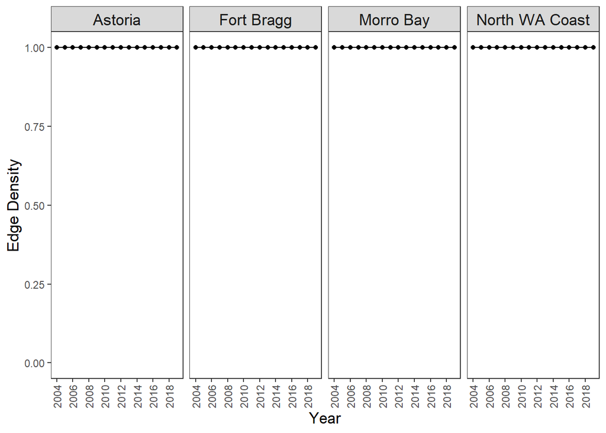

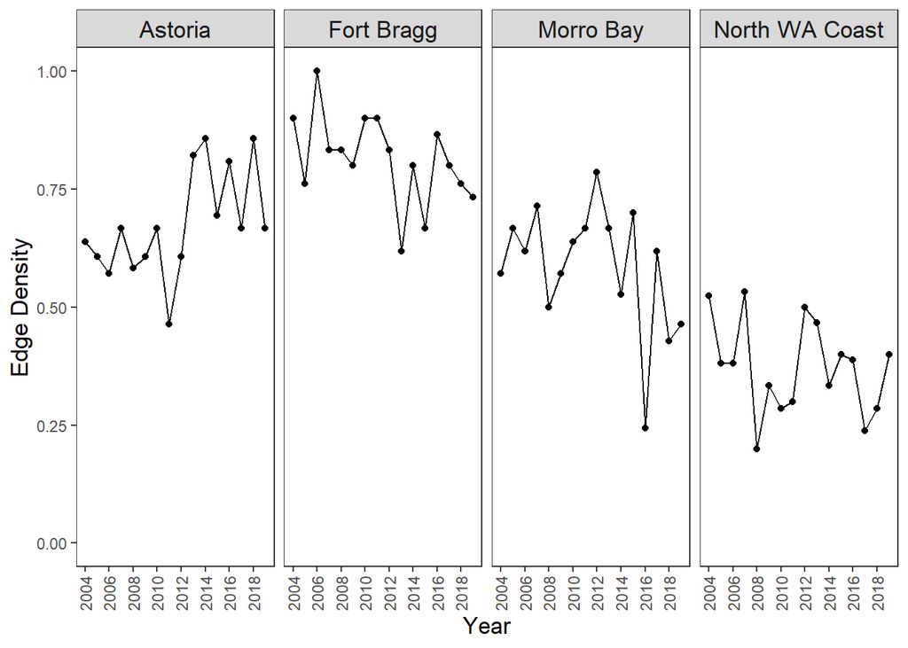

### by State

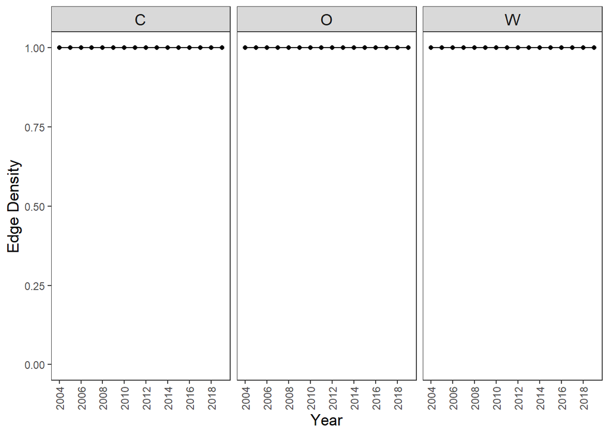

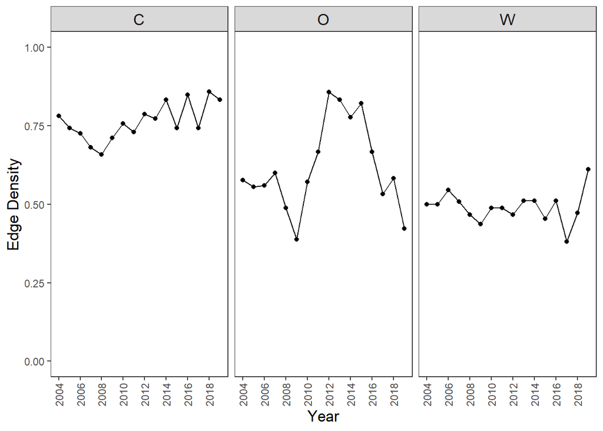

# Centralization

### by Port Group

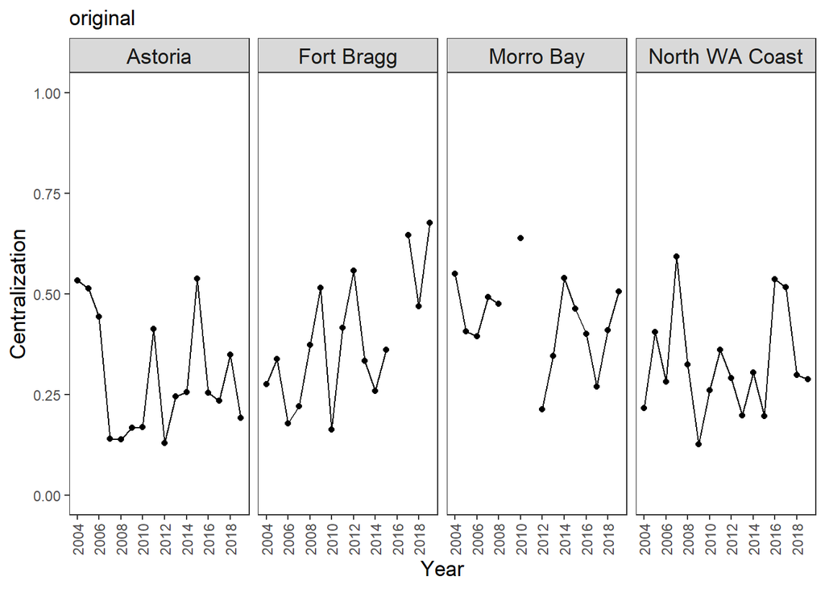

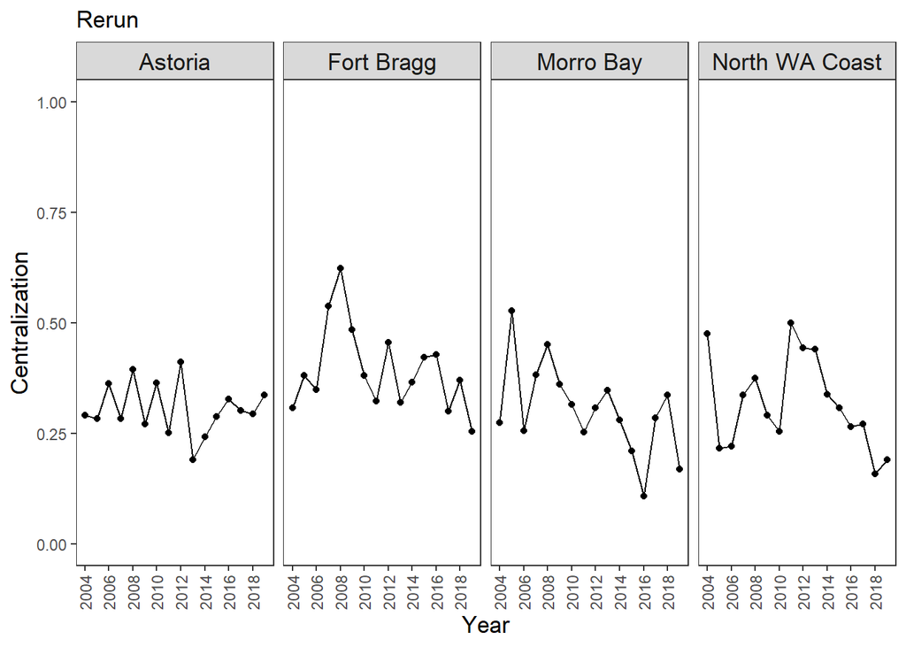

### by State

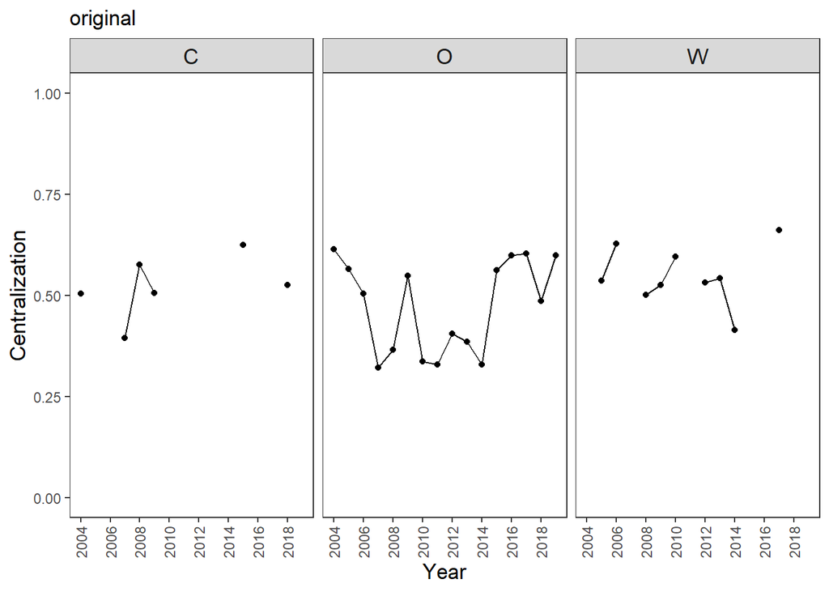

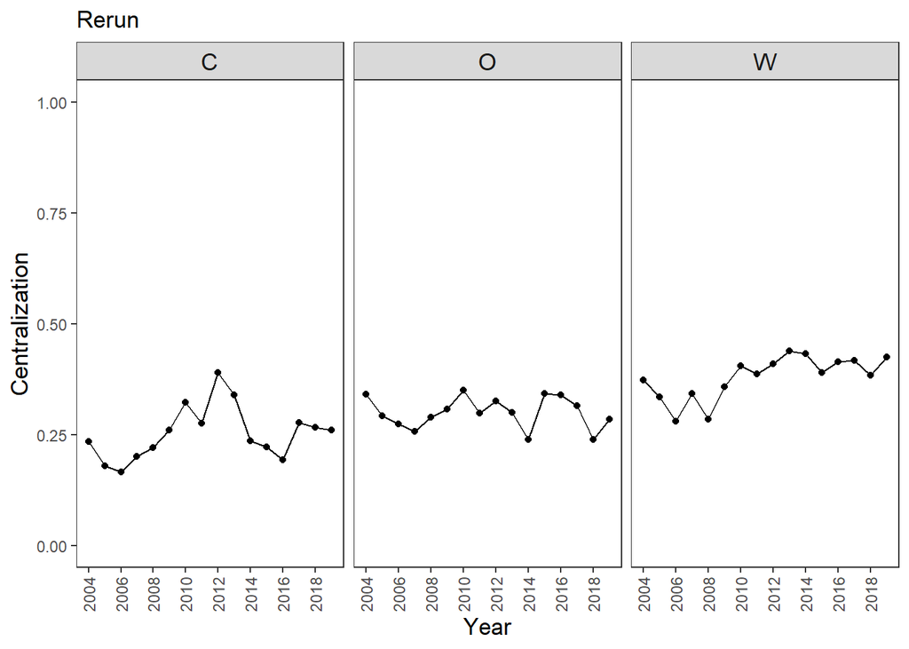

# Aggregate networks

## File Naming

As I was going through the entire script 06, I noticed that the stat filenames for the vessel-level networks and the aggregate networks *are the same*.

### by Port

From **1) Vessel-level networks summarized by port group – B)(ii) and C)(i) A minimum annual total fisheries revenue cutoff for each vessel of $5,000, and a minimum annual individual fisheries revenue cutoff for each vessel of $500.**

```r
# line 415
total_rev_cutoff <- 5000
indiv_rev_cutoff <- 500
edgetype <- "connectivity"

# line 495
filename <- paste0("NetworkStats_", min(years), "_", max(years), "_", length(myports), "pcgroups_", "totalrev", total_rev_cutoff,"_indivrev", indiv_rev_cutoff,"_", edgetype, "_", ifelse(rm_crab, 'rmCrab_','_'), contr_cutoff*100, "pContribution.csv")

filename
```

```
## [1] "NetworkStats_2004_2019_21pcgroups_totalrev5000_indivrev500_connectivity_rmCrab_10pContribution.csv"
```

From **3) Aggregate networks summarized by port – B)(ii) and C)(i) Edges defined based on connectivity.**

```r
# line 969
total_rev_cutoff <- 5000
indiv_rev_cutoff <- 500
edgetype <- "connectivity"

# line 1050
filename <- paste0("NetworkStats_", min(years), "_", max(years), "_", length(myports), "pcgroups_", "totalrev", total_rev_cutoff,"_indivrev", indiv_rev_cutoff,"_", edgetype, "_", ifelse(rm_crab, 'rmCrab_','_'), contr_cutoff*100, "pContribution.csv")
filename
```

```
## [1] "NetworkStats_2004_2019_21pcgroups_totalrev5000_indivrev500_connectivity_rmCrab_10pContribution.csv"
```

### by State

From **2) Vessel-level networks summarized by state – B)(ii) and C)(i) A minimum annual total fisheries revenue cutoff for each vessel of $5,000, and a minimum annual individual fisheries revenue cutoff for each vessel of $500.**

```r
# line 784
total_rev_cutoff <- 5000
indiv_rev_cutoff <- 500
edgetype <- "connectivity"

# line 863
filename <- paste0("NetworkStats_", min(years), "_", max(years), "_", length(mystates), "states_", "totalrev", total_rev_cutoff,"_indivrev", indiv_rev_cutoff,"_", edgetype, "_", ifelse(rm_crab, 'rmCrab_','_'), contr_cutoff*100, "pContribution.csv")
filename
```

```
## [1] "NetworkStats_2004_2019_3states_totalrev5000_indivrev500_connectivity_rmCrab_10pContribution.csv"
```

From **4) Aggregate networks summarized by state – B)(ii) and C)(i) Edges defined based on connectivity.**

```r
# line 1156
total_rev_cutoff <- 5000
indiv_rev_cutoff <- 500
edgetype <- "connectivity"

# line 1239
filename <- paste0("NetworkStats_", min(years), "_", max(years), "_", length(mystates), "states_", "totalrev", total_rev_cutoff,"_indivrev", indiv_rev_cutoff,"_", edgetype, "_", ifelse(rm_crab, 'rmCrab_','_'), contr_cutoff*100, "pContribution.csv")

filename
```

```
## [1] "NetworkStats_2004_2019_3states_totalrev5000_indivrev500_connectivity_rmCrab_10pContribution.csv"
```

## Investigate re-runs

```r
# by port group
file5_name <- paste0("AggNetworkStats_", min(years), "_", max(years), "_", length(myports), "pcgroups_", "totalrev", total_rev_cutoff,"_indivrev", indiv_rev_cutoff,"_", edgetype, "_", ifelse(rm_crab, 'rmCrab_','_'), contr_cutoff*100, "pContribution.csv")

# by state
file6_name <- paste0("AggNetworkStats_", min(years), "_", max(years), "_", length(mystates), "states_", "totalrev", total_rev_cutoff,"_indivrev", indiv_rev_cutoff,"_", edgetype, "_", ifelse(rm_crab, 'rmCrab_','_'), contr_cutoff*100, "pContribution.csv")
```

by port group

```r
rerun_port_agg <- read.csv(here::here('results','statistics',file5_name))
rerun_state_agg <- read.csv(here::here('results','statistics',file6_name))
```

### Edge Density

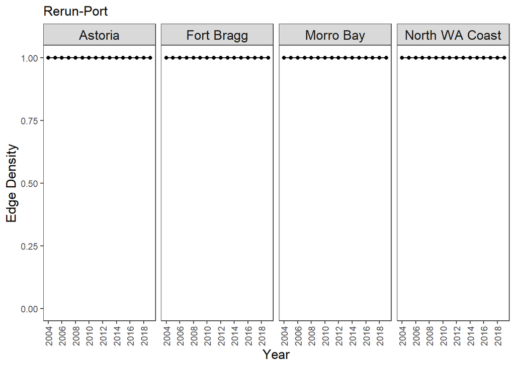

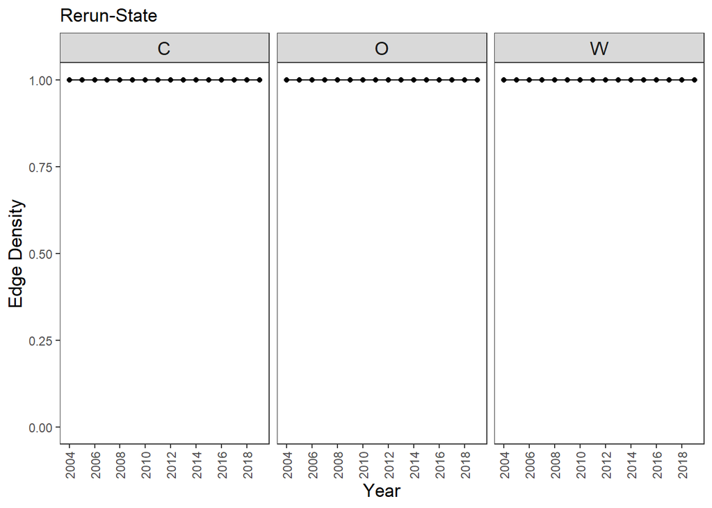

### Network Centralization

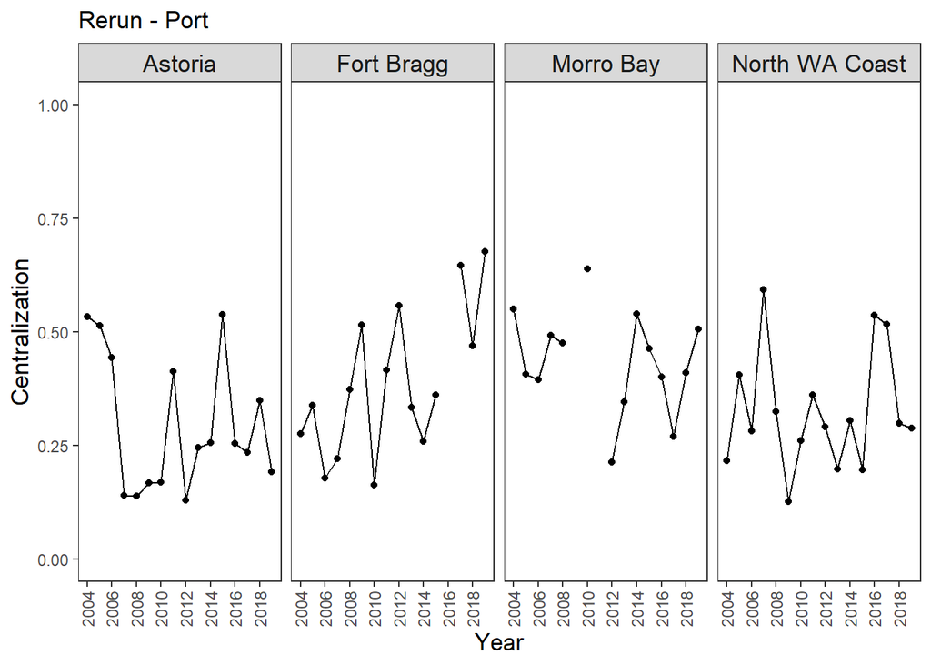

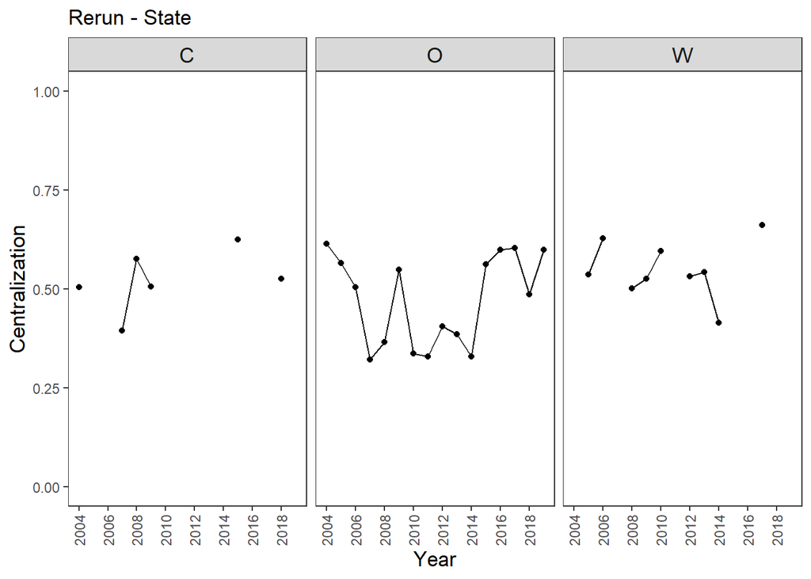